## Do you sleep well and stay invested?

Financial markets are unpredictable by their nature. And that is a big problem as we, humans, prefer certainty and stability. When you are planning to invest for your kid’s college and use the proceeds 10 year from now, you want to make sure that the goals will be met.

Forever increasing productivity - a virtuous engine of capitalism, might come to a rescue, but still how confident you can be that your well earned capital will not be affected?

Below is the possible distribution of the terminal values of 1M invested capital.

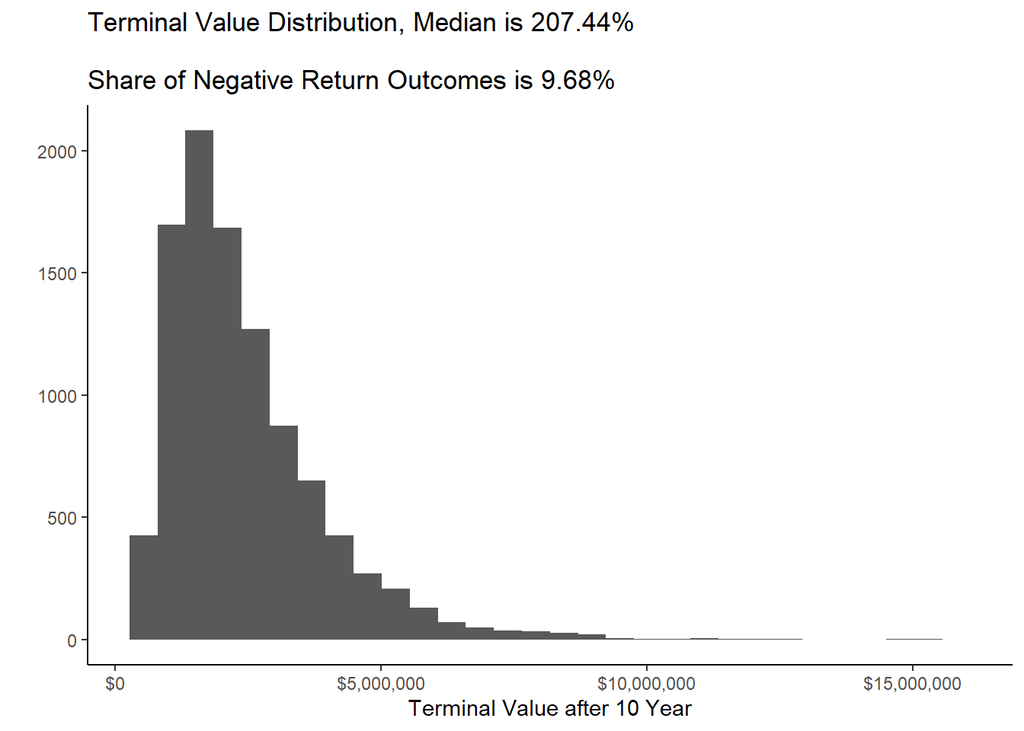

As you see it is not certain that the investments will be recouped. The distribution at the end the investment horizon has a wide range. Note that in real world the investment distributions have fat tails and left skew. This means that large movements to the downside which are missing on a normal distribution are more likely to happen with real portfolios.

Moreover, although the annual expected return is 9%, the effective return is lower. Annual increase of 9% would make 1M to 2.37M. What is the reason behind this? It turns out that if you are not lucky and happened to have a negative return the subsequent return should be much larger to offset the losses. For example if your initial $100 investment had -10% return and then +10%, the average is 0%, but you lost $1 as 10% increase was on a lower base of $90.

Not only the final return might be far from the desired outcome, but during the accumulation phase drawdowns will put a heavy doubt in your mind whether the investment strategy is working or not. Have a look at the maximum drawdown over the investment horizon. Maximum drawdown is the biggest value of the peak to trough your accumulated investment will encounter. So a maximum drawdown of 30% would mean that at some point you will see 30% loss since your best day.

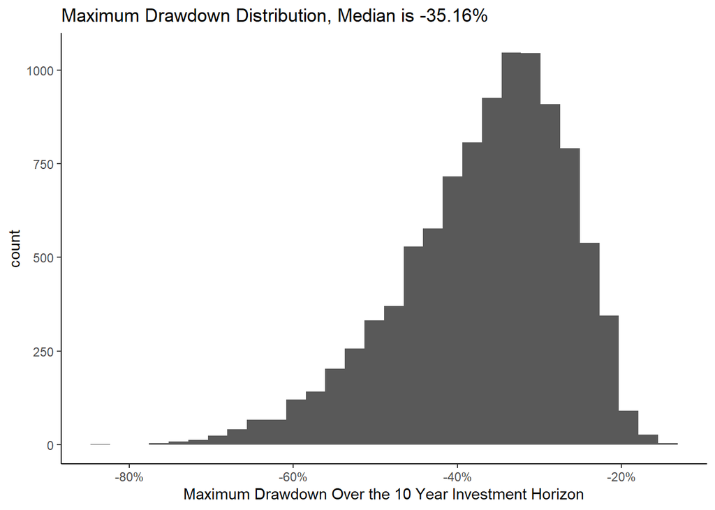

Naturally, longer the investment horizon more likely your portfolio will encounter a large drawdown possibly forcing you to take action, be it a closing the position or increasing the position in a hope of reversal. Those actions of increased trading activity, non systematic changes of the risk profile, and added emotional burden will decrease the potential return of your portfolio.

## Low Volatility Portfolio

Now let’s look at the portfolio which has two times less annual volatility of 10% and slightly lower annual return of 8%.

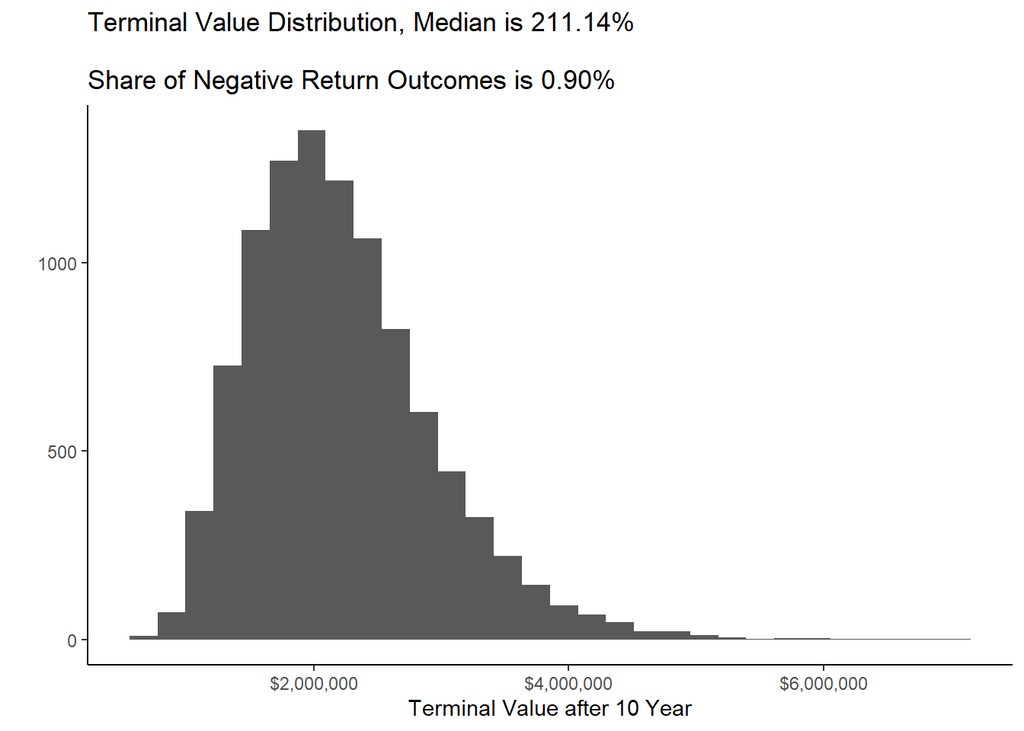

Finally, look at the drawdown chart below.

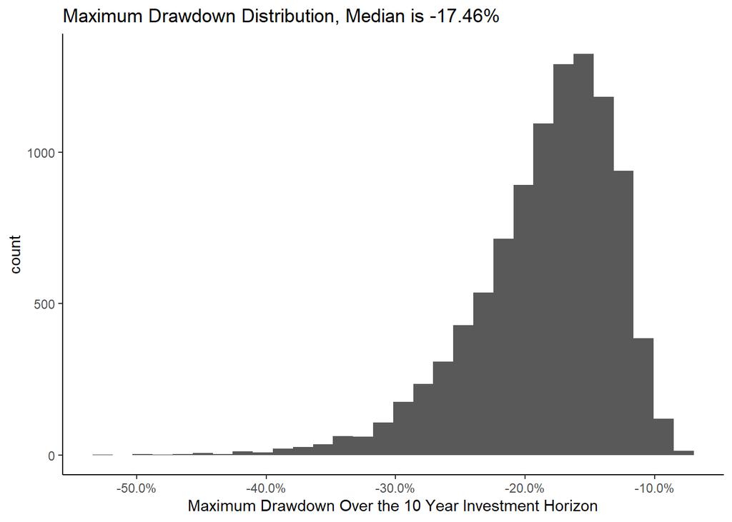

Maximum drawdowns of the less volatile portfolio are much lower. A person carrying such a portfolio will have better emotional and financial wellbeing watching it over the turbulent period.

## Final Remarks

The ratio of expected annual returns over risk free return divided by the expected volatility is the measure you can use to assess risk-adjusted return, assuming that the expected return does not have asymmetric and fat tails. It is called Sharpe Ratio. Higher the Sharpe Ratio - better.
$$SR = {\frac {R - RF}{\sigma}}$$

To sum up, a rule of thumb is that portfolios with lower volatility are better as they provide more stable, higher returns and less chance of overtrading and other actions triggered by emotional reaction.